# Week 3 | In-Class Activity

## Class Activity Part I

We are going to practice creating some plots in `ggplot()`.

### Getting the Data

- Go to: [the course website](https://github.com/byersjs/POLS-5605)
  - Download the `justice_NY_clean` data set
  - Load the `tidyverse` package

### Utilize This Code with a Partner

Load the data

```r
prison <- read_csv("~/Dropbox/Schools/UCONN/Courses/Spring 2025/POLS 5605/Class Activity/Data/justice_NY_clean.csv")
```

1. Create a scatter plot of the Percent Under $25K vs rate.

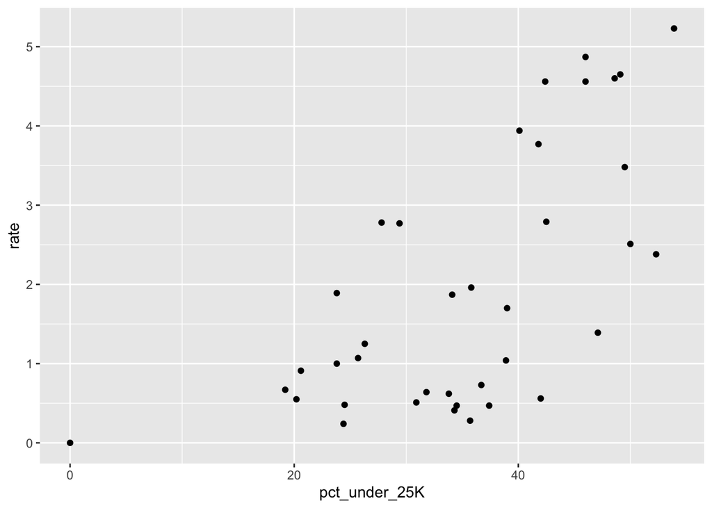

```r
ggplot(data = prison) +
  geom_point(mapping = aes(x = pct_under_25K , y = rate))
```

1. Use aesthetics to indicate cost

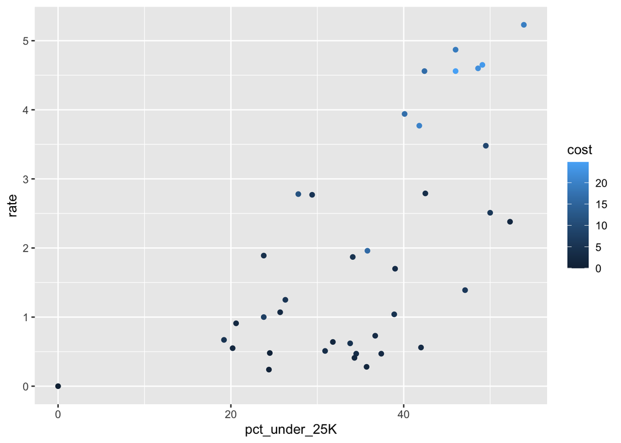

```r
ggplot(data = prison) +
  geom_point(mapping = aes(x = pct_under_25K , y = rate, color = cost))
```

1. Change the size, shape and/or color of all points in your scatterplot

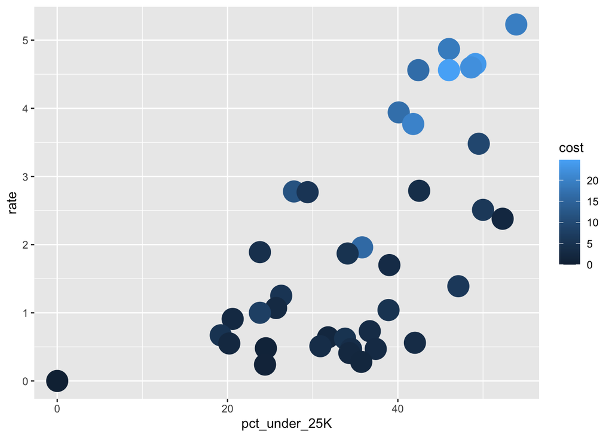

```r
ggplot(data = prison) +
  geom_point(mapping = aes(x = pct_under_25K , y = rate, color = cost), size = 12, shape = 20)
```

## Class Activity Part II

We are going to continue practicing creating plots in `ggplot()`.

### Getting the Data

- Go to: [the course website](https://github.com/byersjs/POLS-5605)
  - Download the `Chetty_2014` data set
  - Load the `tidyverse` package

Load the data

```r
chetty <- read_csv("~/Dropbox/Schools/UCONN/Courses/Spring 2025/POLS 5605/Class Activity/Data/Chetty_2014.csv")
```

1. Visualize the relationship between social capital and absolute mobility. Do you see a correlation? Is it what you expected from the Chetty study executive summary?

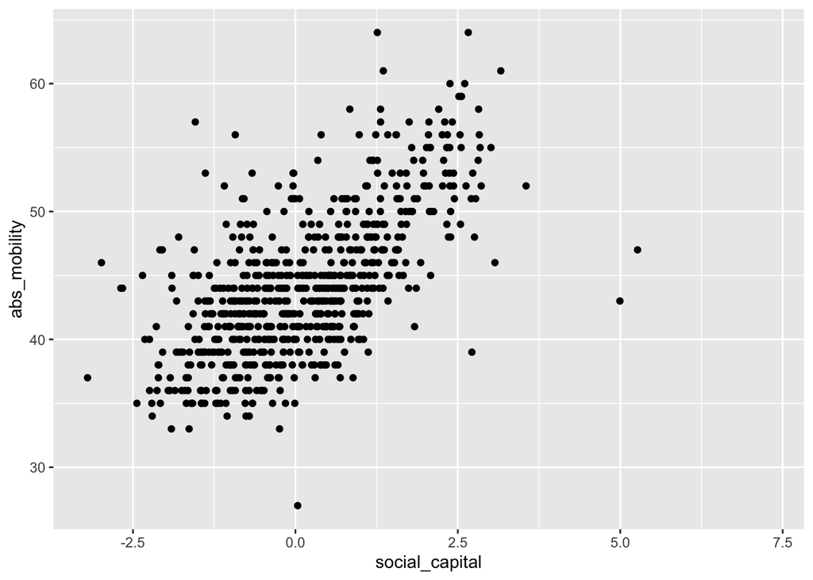

```r
ggplot(data = chetty, mapping = aes(x = social_capital, y = abs_mobility)) +
  geom_point()
```

1. Add an aesthetic to your graph to represent whether the CZ is urban or not.

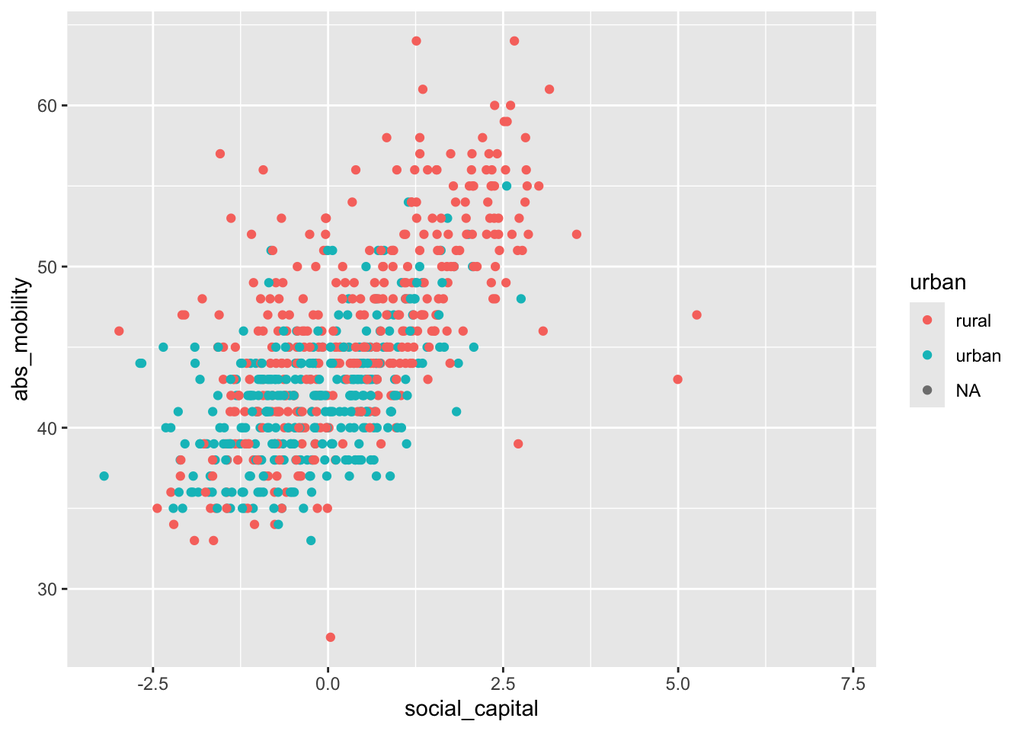

```r
ggplot(data = chetty, mapping = aes(x = social_capital, y = abs_mobility, color = urban)) +
  geom_point()
```

1. Separate urban and non-urban CZ’s into two separate plots.

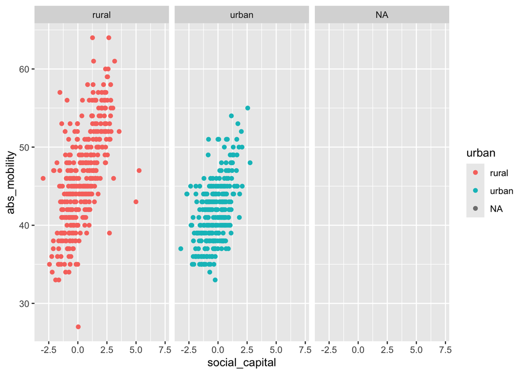

```r
ggplot(data = chetty, mapping = aes(x = social_capital, y = abs_mobility, color = urban)) +
geom_point() + facet_wrap(~ urban)
```

1. Add a smooth fit to each of your plots above. Experiment with adding the option method=“lm” in your geom_smooth. What does this option do?

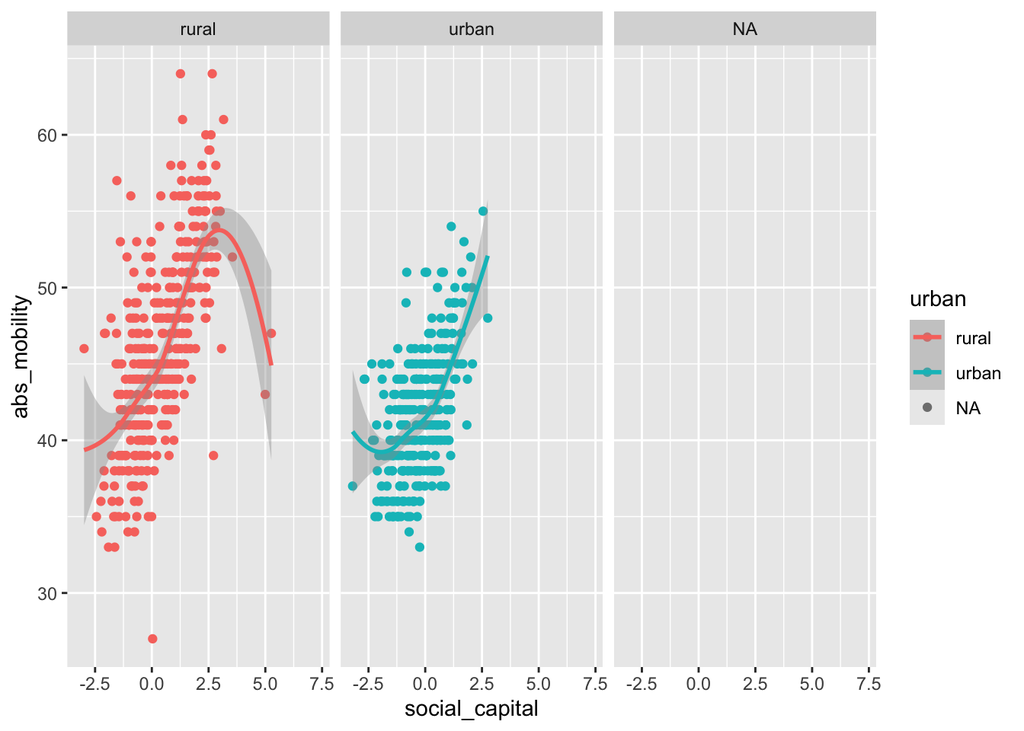

```r
ggplot(data = chetty, mapping = aes(x = social_capital, y = abs_mobility, color = urban)) +
geom_point() +
facet_wrap(~ urban) +
geom_smooth()
```

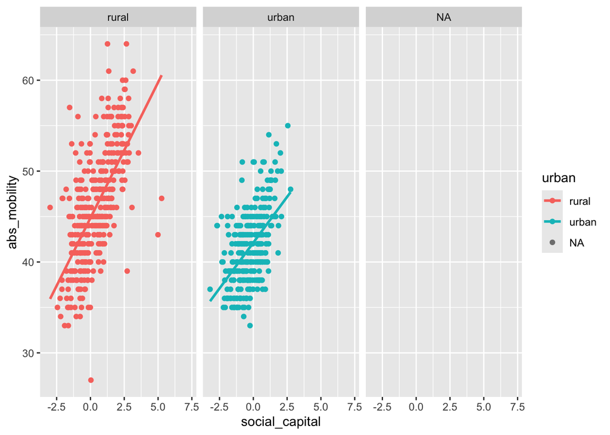

```r
#add method = "lm", se = FALSE to the geom_smooth() function
ggplot(data = chetty, mapping = aes(x = social_capital, y = abs_mobility, color = urban)) +
geom_point() +
facet_wrap(~ urban) +
geom_smooth(method = "lm", se = FALSE)
```

Which variables in the chetty data frame are appropriate x variables for a bar graph?

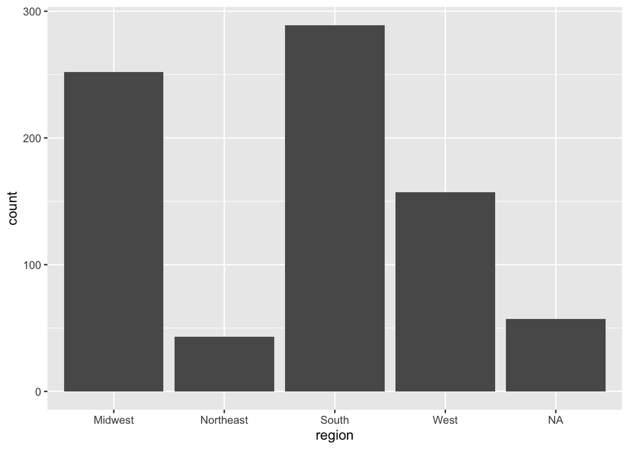

```r
#first plot
ggplot(data=chetty, mapping=aes(x=region)) +
  geom_bar()
```

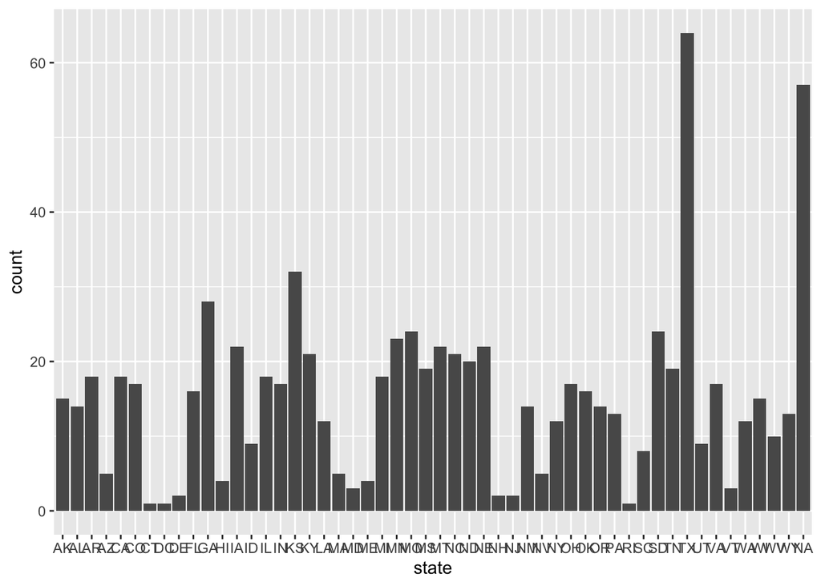

```r
#second plot
ggplot(data=chetty, mapping=aes(x=state)) +
  geom_bar()
```

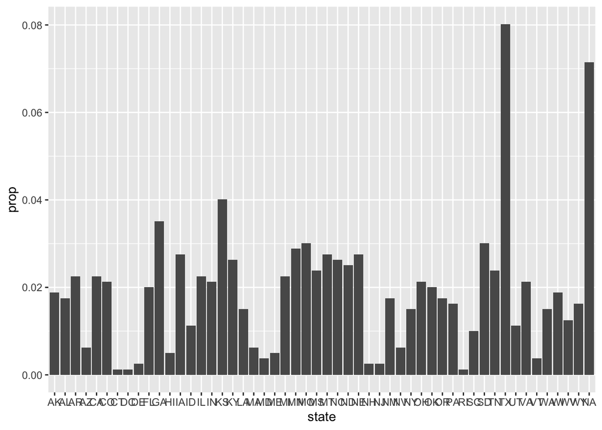

```r
ggplot(data=chetty, mapping=aes(x=state, y = stat(prop), group = 1)) +
  geom_bar()
```

1. Make a bar graph that lets you compare the number of urban and rural CZ’s in each of the four regions

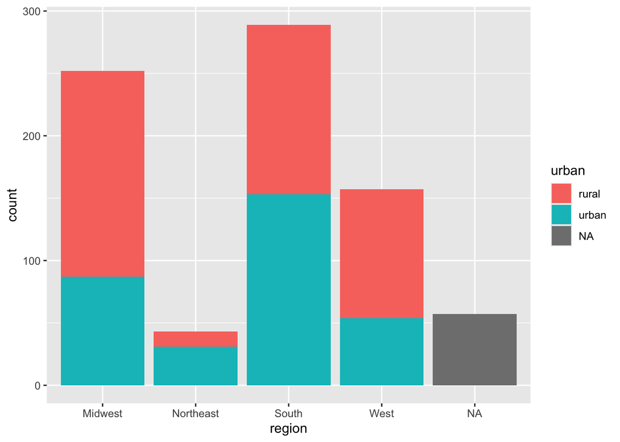

```r
ggplot(data=chetty, mapping=aes(x=region, fill = urban)) +
  geom_bar()
```